# Lab5

Tristen Tooming

2/18/2021

## Assignment 1: Create a spam filter using Support Vector Machines with different kernels

The data file spambase.csv contains information about the frequency of various words, characters etc for a total of 4601 e-mails. Furthermore, these e-mails have been classified as spams (spam = 1) or regular e-mails (spam = 0). Make sure to transform this variable to a factor. Your task is to develop a function based on the SVM model that can be used as a spam filter.

```r
spam = read.csv("spambase.csv", header = T)
spam$Spam = as.factor(spam$Spam)

# Spam = 1, regular = 0
str(spam)
```

```
## 'data.frame':    4601 obs. of  58 variables:
##  $ Word1      : num  0 0.21 0.06 0 0 0 0 0 0.15 0.06 ...
##  $ Word2      : num  0.64 0.28 0 0 0 0 0 0 0 0.12 ...
##  $ Word3      : num  0.64 0.5 0.71 0 0 0 0 0 0.46 0.77 ...
##  $ Word4      : num  0 0 0 0 0 0 0 0 0 0 ...
##  $ Word5      : num  0.32 0.14 1.23 0.63 0.63 1.85 1.92 1.88 0.61 0.19 ...
##  $ Word6      : num  0 0.28 0.19 0 0 0 0 0 0 0.32 ...
##  $ Word7      : num  0 0.21 0.19 0.31 0.31 0 0 0 0.3 0.38 ...
##  $ Word8      : num  0 0.07 0.12 0.63 0.63 1.85 0 1.88 0 0 ...
##  $ Word9      : num  0 0 0.64 0.31 0.31 0 0 0 0.92 0.06 ...
##  $ Word10     : num  0 0.94 0.25 0.63 0.63 0 0.64 0 0.76 0 ...
##  $ Word11     : num  0 0.21 0.38 0.31 0.31 0 0.96 0 0.76 0 ...
##  $ Word12     : num  0.64 0.79 0.45 0.31 0.31 0 1.28 0 0.92 0.64 ...
##  $ Word13     : num  0 0.65 0.12 0.31 0.31 0 0 0 0 0.25 ...
##  $ Word14     : num  0 0.21 0 0 0 0 0 0 0 0 ...
```

[output cut: 44 more lines]

#### 1.a.

Use the tune() function with the svm option in the e1071() library to tune the cost parameter over a reasonable number of values for the linear kernel. Use all data as training data. Tune your procedure by calculating the accuracy and present evidence that you have obtained the best tuning.

```r
library(e1071)

# Tried cost with 0.01, 0.1, 1, 10, 100
# This resulted best model with cost 10
# Used 5:15
svmlincv <- tune(svm, Spam ~.,data=spam,kernel="linear",
             ranges=list(cost=5:15))
```

```r
library(caret)
svmlincv$performances

cat("\n\n Best SVM model with Linear kernel")
best_lin = svmlincv$best.model
summary(best_lin)
confusionMatrix(spam$Spam, predict(best_lin))
```

```
##    cost      error dispersion
## 1     5 0.06890031 0.01368498
## 2     6 0.06803122 0.01413881
## 3     7 0.06759596 0.01494552
## 4     8 0.06781288 0.01445633
## 5     9 0.06824719 0.01333620
## 6    10 0.06802980 0.01379465
## 7    11 0.06802980 0.01449987
## 8    12 0.06802933 0.01446143
## 9    13 0.06802933 0.01446143
## 10   14 0.06781194 0.01452460
## 11   15 0.06759455 0.01461986
##
##
##  Best SVM model with Linear kernel
## Call:
## best.tune(method = svm, train.x = Spam ~ ., data = spam, ranges = list(cost = 5:15),
##     kernel = "linear")
##
##
## Parameters:
##    SVM-Type:  C-classification
##  SVM-Kernel:  linear
##        cost:  15
##
## Number of Support Vectors:  935
##
##  ( 447 488 )
##
##
## Number of Classes:  2
##
## Levels:
##  0 1
##
##
##
## Confusion Matrix and Statistics
##
##           Reference
```

[output cut: 9 more lines]

```
##                   Kappa : 0.8646
##
##  Mcnemar's Test P-Value : 0.00139
##
##             Sensitivity : 0.9381
##             Specificity : 0.9317
##          Pos Pred Value : 0.9570
##          Neg Pred Value : 0.9029
##              Prevalence : 0.6181
##          Detection Rate : 0.5799
##    Detection Prevalence : 0.6060
##       Balanced Accuracy : 0.9349
##
##        'Positive' Class : 0
##
```

#### 1.b.

Repeat the analysis in 1.a. with the radial basis function kernel, calculate new accuracies and provide evidence for the best model.

```r
svmradcv <- tune(svm, Spam ~.,data=spam,kernel="radial",
             ranges=list(cost=c(0.01, 0.1, 1, 2, 3, 4, 5, 6)))
```

```r
svmradcv$performances

cat("\n\n Best SVM model with Radial kernel")
best_rad = svmradcv$best.model
summary(best_rad)
confusionMatrix(spam$Spam, predict(best_rad))
```

```
##   cost      error  dispersion
## 1 0.01 0.20799491 0.017434772
## 2 0.10 0.08846034 0.012266539
## 3 1.00 0.06694237 0.007994298
## 4 2.00 0.06455154 0.008821303
## 5 3.00 0.06563850 0.008688238
## 6 4.00 0.06368292 0.009732089
## 7 5.00 0.06324861 0.010228757
## 8 6.00 0.06281383 0.010020719
##
##
##  Best SVM model with Radial kernel
## Call:
## best.tune(method = svm, train.x = Spam ~ ., data = spam, ranges = list(cost = c(0.01,
##     0.1, 1, 2, 3, 4, 5, 6)), kernel = "radial")
##
##
## Parameters:
##    SVM-Type:  C-classification
##  SVM-Kernel:  radial
##        cost:  6
##
## Number of Support Vectors:  1077
##
##  ( 510 567 )
##
##
## Number of Classes:  2
##
## Levels:
##  0 1
##
##
##
## Confusion Matrix and Statistics
##
##           Reference
## Prediction    0    1
##          0 2732   56
##          1  118 1695
##
##                Accuracy : 0.9622
##                  95% CI : (0.9563, 0.9675)
##     No Information Rate : 0.6194
##     P-Value [Acc > NIR] : < 2.2e-16
##
##                   Kappa : 0.9203
##
##  Mcnemar's Test P-Value : 3.757e-06
##
##             Sensitivity : 0.9586
##             Specificity : 0.9680
##          Pos Pred Value : 0.9799
##          Neg Pred Value : 0.9349
##              Prevalence : 0.6194
##          Detection Rate : 0.5938
##    Detection Prevalence : 0.6060
##       Balanced Accuracy : 0.9633
##
##        'Positive' Class : 0
##
```

> Radial has a better accuracy

1.c. Based on the results from 1.a. and 1.b. present a function of the best method that reads new test observations and outputs the prediction if the mail was a spam or not.

```r
check_if_spam = function(data) {
  # words as a vector
  prediction = predict(best_rad, data)
  if (prediction == 1) {
    cat("\nAnswer: SPAM SPAM SPAM. No need to read")
  }
  else {
    cat("\nAnswer: You can read this email")
  }

}

for (i in c(2000, 1, 15, 25)) {
  check_if_spam(spam[i, ])
  if (as.integer(as.character(spam$Spam[i])) == 1) {
    cat("\nCorrect: SPAM \n")
  } else {
    cat("\nCorrect: Not a Spam \n")
  }
}


data = as.numeric(levels(spam$Spam))[spam$Spam]
```

```
##
## Answer: You can read this email
## Correct: Not a Spam
##
## Answer: SPAM SPAM SPAM. No need to read
## Correct: SPAM
##
## Answer: SPAM SPAM SPAM. No need to read
## Correct: SPAM
##
## Answer: You can read this email
## Correct: SPAM
```

## Assignment 2: Investigate the prediction properties of the Support Vector Regression method with different kernels

In Lab 3_2, you investigated how the Lasso and different GAM models performed on the auto-mpg.txt data which concerns city-cycle fuel consumption in miles per gallon, to be predicted in terms of 3 multivalued discrete and 5 continuous attributes. Follow the instructions there regarding the data. Your task is to compare the results from the GAM models with the prediction properties of Support Vector Regression (SVR) with different kernels using the kernlab and caret packages.

```r
library(caret)
library(kernlab)
auto_mpg = read.table('auto-mpg.txt', header = T)

auto_mpg$year = factor(auto_mpg$year)
auto_mpg$origin = factor(auto_mpg$origin)

auto_mpg = auto_mpg[ , !(names(auto_mpg) %in% 'name')]

summary(auto_mpg)
```

```
##       mpg          cylinders      displacement     horsepower        weight
##  Min.   : 9.00   Min.   :3.000   Min.   : 68.0   Min.   : 46.0   Min.   :1613
##  1st Qu.:17.00   1st Qu.:4.000   1st Qu.:105.0   1st Qu.: 75.0   1st Qu.:2225
##  Median :22.75   Median :4.000   Median :151.0   Median : 93.5   Median :2804
##  Mean   :23.45   Mean   :5.472   Mean   :194.4   Mean   :104.5   Mean   :2978
##  3rd Qu.:29.00   3rd Qu.:8.000   3rd Qu.:275.8   3rd Qu.:126.0   3rd Qu.:3615
##  Max.   :46.60   Max.   :8.000   Max.   :455.0   Max.   :230.0   Max.   :5140
##
##   acceleration        year     origin
##  Min.   : 8.00   73     : 40   1:245
##  1st Qu.:13.78   78     : 36   2: 68
##  Median :15.50   76     : 34   3: 79
##  Mean   :15.54   75     : 30
##  3rd Qu.:17.02   82     : 30
##  Max.   :24.80   70     : 29
##                  (Other):193
```

2.a. Set up a SVR model with the linear kernel function for all data with the train() function in the caret package and use LOOCV to find the best RMSE. Find a reasonable interval for the tuning parameter C. Present the table of the evaluated models and their model fit criteria.

```r
# Build the SWM model with linear kernel and find best
# model with LOOCV tuning the cost parameter
svm_lin <- train(
  mpg~., data = auto_mpg, method = "svmLinear",
  trControl = trainControl("LOOCV"),
  tuneGrid = expand.grid(C = seq(0.7,1, length = 30)))
```

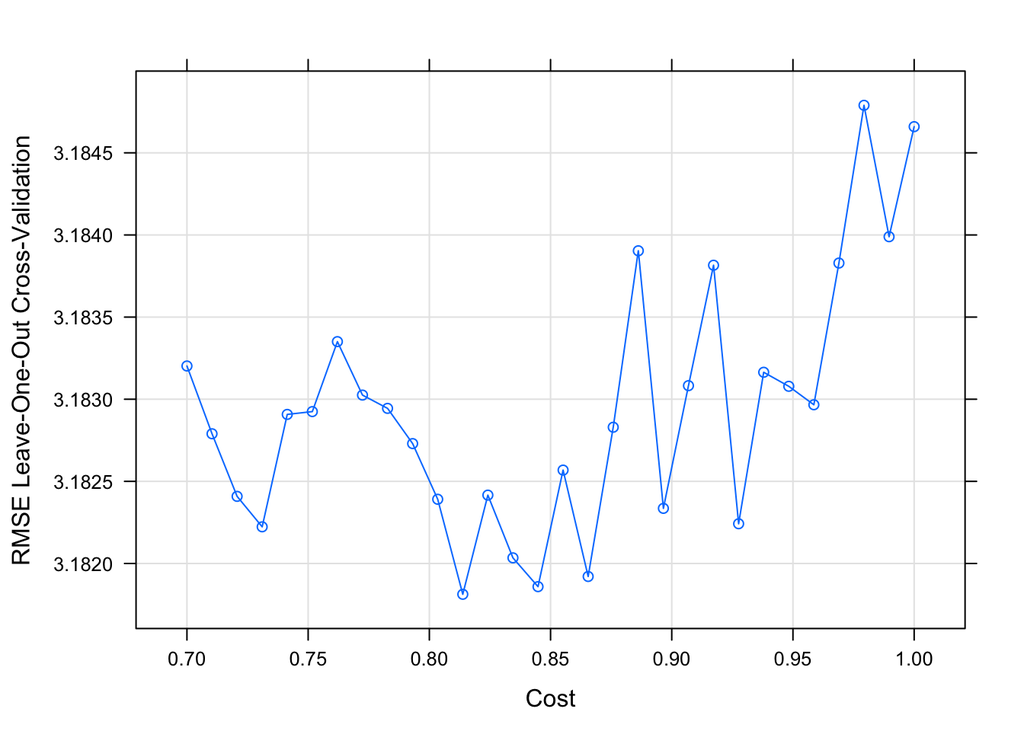

```
## Best RMSE: 3.182
```

```r
cat(sprintf("Best RMSE: %.3f\n", min(svm_lin$results$RMSE)))
plot(svm_lin)
```

2.b. Set up a SVR model with the radial basis kernel function for all data with the train() function in the caret package and use LOOCV to find the RMSE. Find a reasonable interval for the tuning parameter C. Present the table of the evaluated models and their model fit criteria.

```r
# Build the SWM model with linear kernel and find best
# model with LOOCV tuning the cost parameter
svm_rad <- train(
  mpg~., data = auto_mpg, method = "svmRadial",
  trControl = trainControl("LOOCV"),
  tuneGrid = expand.grid(C = 3:10,
                      sigma = seq(0.001,0.2,length = 10)))
```

```r
svm_rad
```

```
## Support Vector Machines with Radial Basis Function Kernel
##
## 392 samples
##   7 predictor
##
## No pre-processing
## Resampling: Leave-One-Out Cross-Validation
## Summary of sample sizes: 391, 391, 391, 391, 391, 391, ...
## Resampling results across tuning parameters:
##
##   sigma       C   RMSE      Rsquared   MAE
##   0.00100000   3  3.305546  0.8303148  2.379374
##   0.00100000   4  3.281390  0.8312410  2.371347
##   0.00100000   5  3.264574  0.8314646  2.357343
##   0.00100000   6  3.190953  0.8378795  2.298482
##   0.00100000   7  3.156825  0.8410277  2.274752
##   0.00100000   8  3.122448  0.8440614  2.261110
##   0.00100000   9  3.083295  0.8477955  2.233136
##   0.00100000  10  3.042767  0.8518073  2.196686
##   0.02311111   3  2.852851  0.8662621  1.980030
##   0.02311111   4  2.858772  0.8655894  1.980100
##   0.02311111   5  2.845918  0.8667584  1.970019
##   0.02311111   6  2.840528  0.8672619  1.964779
##   0.02311111   7  2.842637  0.8670868  1.968713
##   0.02311111   8  2.846582  0.8667548  1.972398
##   0.02311111   9  2.854600  0.8660639  1.976307
##   0.02311111  10  2.871816  0.8645191  1.987556
##   0.04522222   3  2.858843  0.8656082  1.985453
##   0.04522222   4  2.894699  0.8621924  2.004870
##   0.04522222   5  2.920824  0.8597786  2.014152
##   0.04522222   6  2.933462  0.8586541  2.018976
##   0.04522222   7  2.946733  0.8574608  2.022881
##   0.04522222   8  2.957162  0.8565188  2.027173
##   0.04522222   9  2.960715  0.8562257  2.026794
##   0.04522222  10  2.965266  0.8558225  2.028432
##   0.06733333   3  2.930157  0.8588239  2.032335
##   0.06733333   4  2.947018  0.8571787  2.037010
##   0.06733333   5  2.965618  0.8554147  2.049739
##   0.06733333   6  2.982437  0.8538306  2.055187
##   0.06733333   7  2.994544  0.8527010  2.055801
```

[output cut: 39 more lines]

```
##   0.17788889   7  3.237829  0.8275346  2.202252
##   0.17788889   8  3.262435  0.8249792  2.207903
##   0.17788889   9  3.282846  0.8228799  2.219793
##   0.17788889  10  3.301723  0.8209506  2.236257
##   0.20000000   3  3.133731  0.8393355  2.160223
##   0.20000000   4  3.169616  0.8350780  2.172863
##   0.20000000   5  3.206411  0.8309464  2.191122
##   0.20000000   6  3.243116  0.8269307  2.209888
##   0.20000000   7  3.269623  0.8240873  2.218988
##   0.20000000   8  3.287099  0.8222341  2.228454
##   0.20000000   9  3.306224  0.8202208  2.241612
##   0.20000000  10  3.325811  0.8181829  2.254313
##
## RMSE was used to select the optimal model using the smallest value.
## The final values used for the model were sigma = 0.02311111 and C = 6.
```

```r
cat(sprintf("Best RMSE: %.3f\n", min(svm_rad$results$RMSE)))
```

```
## Best RMSE: 2.841
```

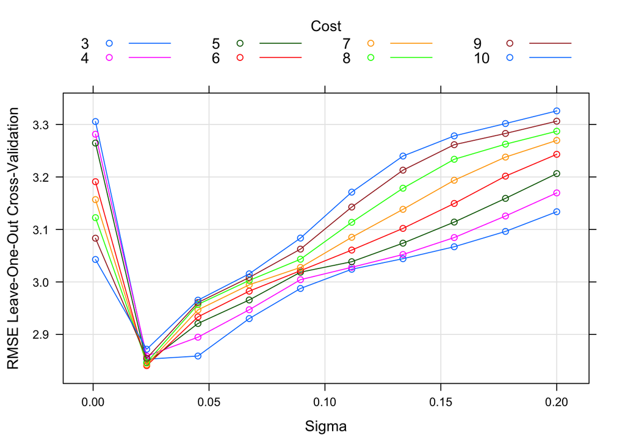

```r
plot(svm_rad)
```

2.c. Set up a SVR model with the BRF kernel function for all data with the train() function in the caret package and use LOOCV to find the RMSE. Find a reasonable interval for the tuning parameter C and sigma. Present the table of the evaluated models and their model fit criteria.

```r
# Build the SVR model with RBF kernel and find best model with
# LOOCV tuning the cost
parameter_svr_rbf <- train(
  mpg~., data = auto_mpg, method = "svmRadialCost",
  trControl = trainControl(method = "LOOCV"),
  tuneGrid = expand.grid(C = seq(2, 4, length.out = 30)))
```

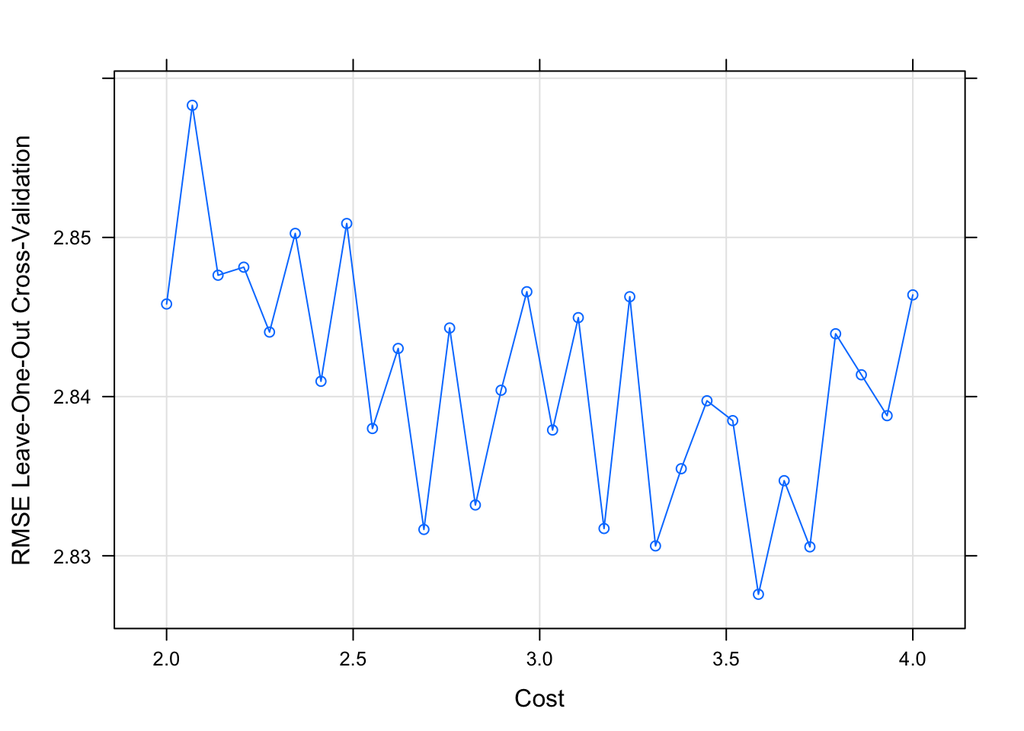

```
## Support Vector Machines with Radial Basis Function Kernel
##
## 392 samples
##   7 predictor
##
## No pre-processing
## Resampling: Leave-One-Out Cross-Validation
## Summary of sample sizes: 391, 391, 391, 391, 391, 391, ...
## Resampling results across tuning parameters:
##
##   C         RMSE      Rsquared   MAE
##   2.000000  2.845817  0.8672030  1.964011
##   2.068966  2.858300  0.8659521  1.974250
##   2.137931  2.847624  0.8669766  1.975898
##   2.206897  2.848131  0.8669222  1.969029
##   2.275862  2.844053  0.8672414  1.968694
##   2.344828  2.850254  0.8665900  1.972817
##   2.413793  2.840960  0.8675050  1.969107
##   2.482759  2.850874  0.8664889  1.967317
##   2.551724  2.837994  0.8677276  1.965165
##   2.620690  2.843024  0.8672518  1.965959
##   2.689655  2.831652  0.8682871  1.962237
##   2.758621  2.844312  0.8670483  1.975210
##   2.827586  2.833190  0.8680979  1.966264
##   2.896552  2.840399  0.8674254  1.965255
##   2.965517  2.846589  0.8667869  1.973744
##   3.034483  2.837899  0.8675912  1.964165
##   3.103448  2.844961  0.8669248  1.964106
##   3.172414  2.831712  0.8681652  1.959328
##   3.241379  2.846275  0.8667873  1.968125
##   3.310345  2.830619  0.8682721  1.958522
##   3.379310  2.835469  0.8677717  1.969060
##   3.448276  2.839738  0.8673528  1.968467
##   3.517241  2.838490  0.8674651  1.960965
##   3.586207  2.827579  0.8684822  1.961923
##   3.655172  2.834718  0.8678109  1.966886
##   3.724138  2.830558  0.8682038  1.965849
##   3.793103  2.843948  0.8669533  1.965663
##   3.862069  2.841370  0.8671721  1.972239
##   3.931034  2.838802  0.8674057  1.971887
##   4.000000  2.846390  0.8667220  1.966872
##
## RMSE was used to select the optimal model using the smallest value.
## The final value used for the model was C = 3.586207.
## Best RMSE: 2.828
```

```r
parameter_svr_rbf
cat(sprintf("Best RMSE: %.3f\n", min(parameter_svr_rbf$results$RMSE)))
plot(parameter_svr_rbf)
```

2.d. How did the SVR models perform in comparison with the LASSO and GAM models? Provide a discussion that not only takes MSE into account but also computing time.

Parameter tuning

SVM Lin performed worst when comparing with RMSE. SVM Rad had the longest computing time and needed most tweaking (two expensive parameters to tune). Overall support vector machines are more cost expensive, more demanding to tune and the models are complexier compared to general additive models and specially with Lasso. With GAM and Lasso you can easily see the effect of the variables and deep dive the models diagnostics.